# micro-RNA Heart Transplantation

### Data importing

```
✓ Configuration loaded successfully
✓ Configuration for transplantation loaded successfully

============================================================
LOADING AND PROCESSING DATA
============================================================

Loading phenotable data...
   File: /Users/dariakilina/GitHub/ncRNA_pipeline/Transplantation/data/phenotable.tsv
   ✓ Loaded 30 samples
   ✓ Groups: ACR, AMR, CAV, NR

 Loading counts data...
   File: /Users/dariakilina/GitHub/ncRNA_pipeline/data/raw/miR.Counts.csv
   ✓ Loaded 2731 features × 49 samples

 Cleaning sample names...
   ✓ No cleaning needed

🔗 Matching samples between counts and phenotable...
   Counts:    49 samples
   phenotable: 30 samples
   Common:    30 samples
 19 counts samples not in phenotable
   ✓ Sample order verified

 Filtering low-expressed features...
   Smallest group size: 6 samples
   Threshold: >= 10 counts in >= 6 samples
   ✓ Kept 561 / 2731 features (20.5%)
   ✓ Removed 2170 low-expressed features

============================================================
✅ DATA PROCESSING COMPLETE
============================================================

Final dataset: 561 features × 30 samples
Groups: ACR, AMR, CAV, NR
Samples per group:

ACR AMR CAV  NR
  8   6   7   9

📋 Loading sample annotation...
   File: /Users/dariakilina/GitHub/ncRNA_pipeline/data/raw/annotation.report.csv
   ✓ Loaded 49 samples × 15 columns
   ✓ Retained 9 columns after filtering

🔗 Matching annotation with phenotype...
   Annotation samples: 49
   Phenotype samples:  30
   Common samples:     30
   ✓ Annotation successfully aligned
```

**Venn plot (>150 counts)**

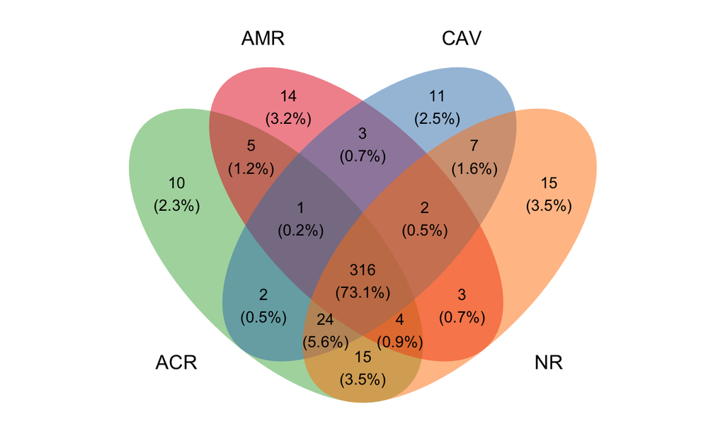

**Unique miRs**

```
$ACR
 [1] "hsa-miR-1255a"    "hsa-miR-330-5p"   "hsa-miR-331-3p"   "hsa-miR-4433b-3p" "hsa-miR-487b-3p"  "hsa-miR-493-3p"
 [7] "hsa-miR-493-5p"   "hsa-miR-610"      "hsa-miR-6513-3p"  "hsa-miR-708-3p"

$AMR
 [1] "hsa-miR-194-3p"                             "hsa-miR-3065-5p"
 [3] "hsa-miR-3128"                               "hsa-miR-326-3p"
 [5] "hsa-miR-365a-3p/365b-3p"                    "hsa-miR-370-3p"
 [7] "hsa-miR-378a-5p"                            "hsa-miR-378i"
 [9] "hsa-miR-455-5p"                             "hsa-miR-485-5p"
[11] "hsa-miR-499a-5p"                            "hsa-miR-548ae-3p/548aj-3p/548aq-3p/548x-3p"
[13] "hsa-miR-548ah-3p/548am-3p"                  "hsa-miR-618-5p"

$CAV
 [1] "hsa-miR-10a-3p"  "hsa-miR-1303-3p" "hsa-miR-218-5p"  "hsa-miR-29c-5p"  "hsa-miR-3135a"   "hsa-miR-362-5p"  "hsa-miR-4638-3p"
 [8] "hsa-miR-4755-3p" "hsa-miR-539-3p"  "hsa-miR-570-3p"  "hsa-miR-641"

$NR
 [1] "hsa-miR-190b-5p"           "hsa-miR-193a-3p"           "hsa-miR-219a-1-3p"         "hsa-miR-3163"
 [5] "hsa-miR-3691-5p"           "hsa-miR-4659a-3p/4659b-3p" "hsa-miR-4772-5p"           "hsa-miR-4999-5p"
 [9] "hsa-miR-6511b-5p"          "hsa-miR-652-5p"            "hsa-miR-660-3p"            "hsa-miR-6741-3p"
[13] "hsa-miR-6780a-5p"          "hsa-miR-6884-5p"           "hsa-miR-7705"
```

**Barplots**

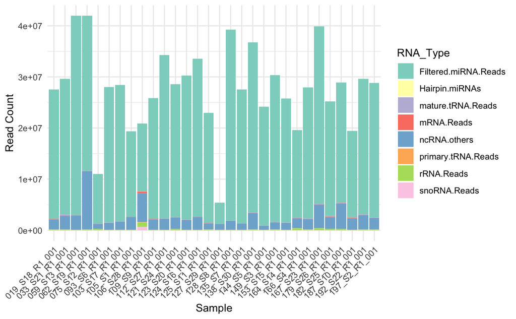

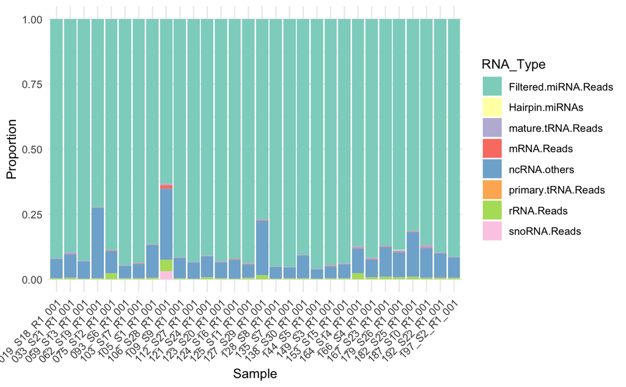

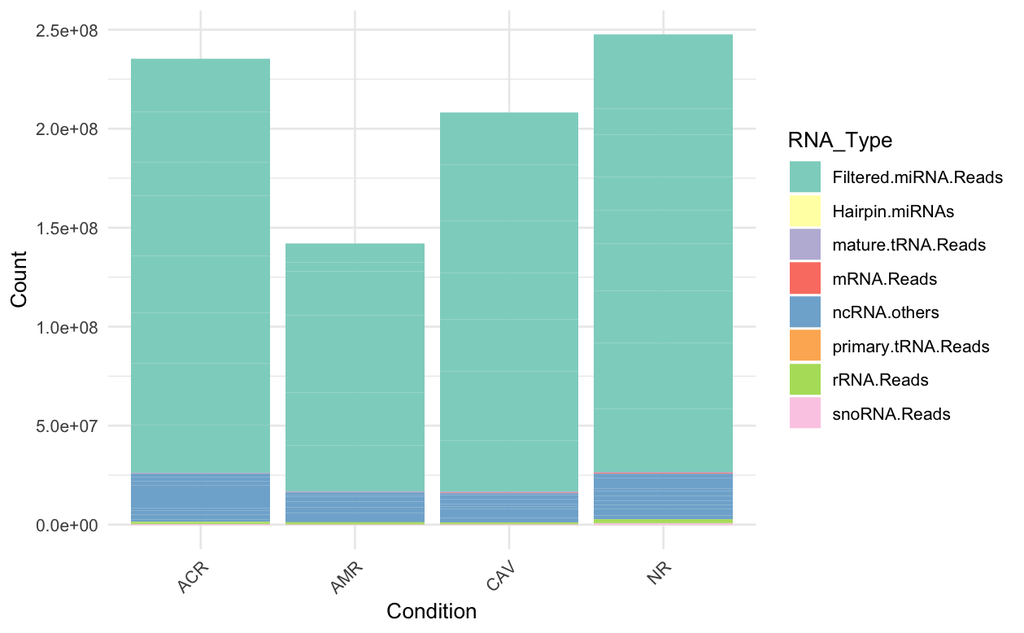

### Run Differential Expression Analysis

```
Rank of model matrix: 4
Number of columns: 4
class: DESeqDataSet
dim: 561 30
metadata(1): version
assays(6): counts mu ... replaceCounts replaceCooks
rownames(561): hsa-let-7a-3p hsa-let-7a-5p/7c-5p ... hsa-miR-99b-3p hsa-miR-99b-5p
rowData names(31): baseMean baseVar ... maxCooks replace
colnames(30): 182_S25_R1_001 112_S27_R1_001 ... 103_S17_R1_001 128_S8_R1_001
colData names(4): sample condition sizeFactor replaceable
```

**transformation**

```
Samples: 30
Genes: 561
Using rlog transformation
```

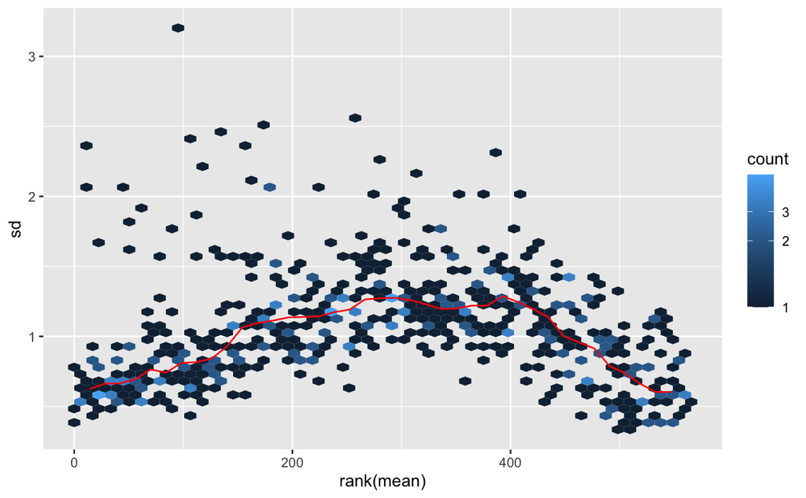

```
$transformed
class: DESeqTransform
dim: 561 30
metadata(1): version
assays(1): ''
rownames(561): hsa-let-7a-3p hsa-let-7a-5p/7c-5p ... hsa-miR-99b-3p hsa-miR-99b-5p
rowData names(32): baseMean baseVar ... replace rlogIntercept
colnames(30): 182_S25_R1_001 112_S27_R1_001 ... 103_S17_R1_001 128_S8_R1_001
colData names(4): sample condition sizeFactor replaceable

$method
[1] "rlog"
```

**PCA plot**

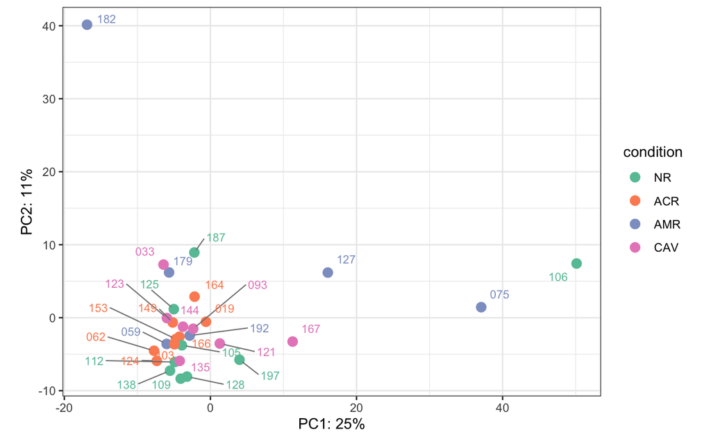

**Plot a heatmap of most variable genes**

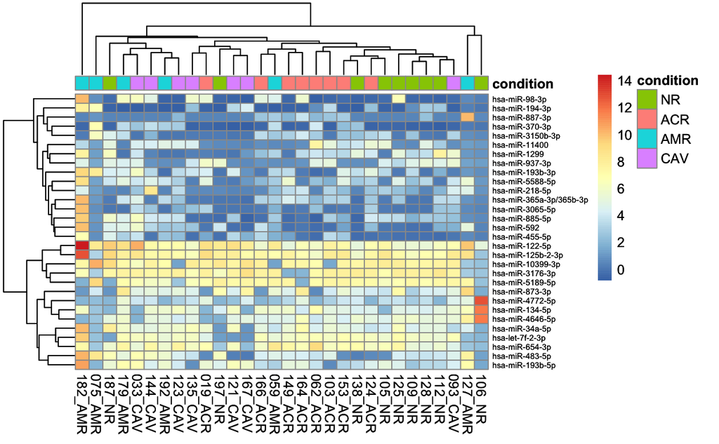

**Plot of the distance between samples heatmap**

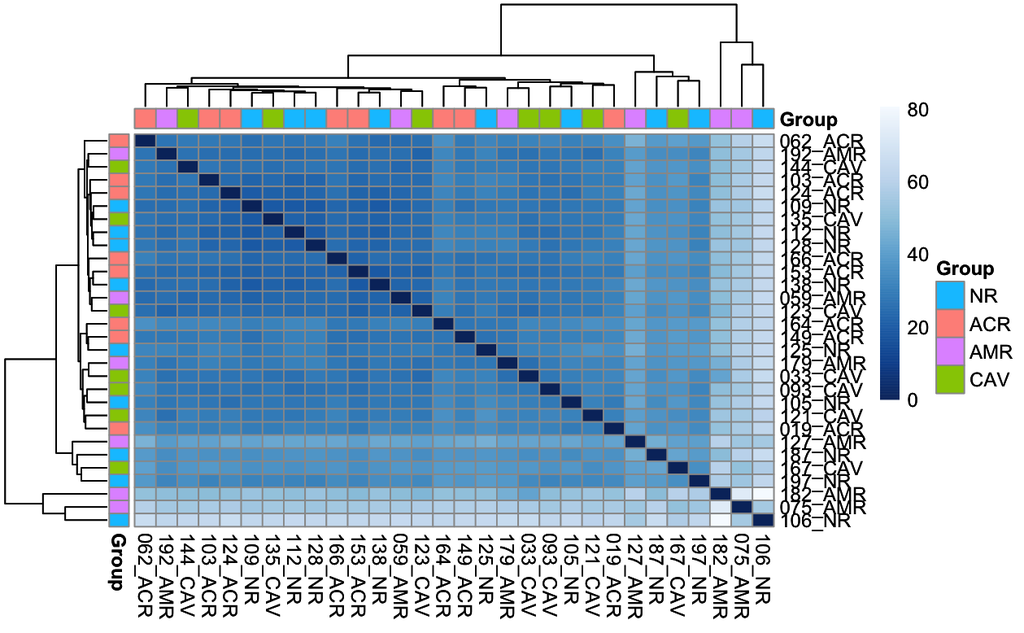

## Results

```
Significant results saved to: results/results_humoral.csv
Significant results saved to: results/sign_results_humoral.csv
Significant results saved to: results/results_cellular.csv
Significant results saved to: results/sign_results_cellular.csv
Significant results saved to: results/results_CAV.csv
Significant results saved to: results/sign_results_CAV.csv
```

|  | baseMean | log2FoldChange | lfcSE | stat | pvalue | padj |
| --- | --- | --- | --- | --- | --- | --- |
| hsa-miR-100-5p | 1148.94454 | 3.065068 | 0.6535613 | 4.689794 | 2.734798e-06 | 3.837833e-04 |
| hsa-miR-125b-5p | 333.32963 | 2.693872 | 0.7112570 | 3.787480 | 1.521827e-04 | 9.152704e-03 |
| hsa-miR-1468-5p | 327.46663 | 3.128524 | 0.5977271 | 5.234034 | 1.658498e-07 | 6.982279e-05 |
| hsa-miR-146a-5p | 5515.39892 | 1.752041 | 0.5052964 | 3.467354 | 5.256089e-04 | 1.844011e-02 |
| hsa-miR-152-3p | 235.52915 | 2.540286 | 0.7072375 | 3.591843 | 3.283471e-04 | 1.555142e-02 |
| hsa-miR-193b-3p | 95.23409 | 5.806075 | 1.6426147 | 3.534654 | 4.083094e-04 | 1.718982e-02 |
| hsa-miR-193b-5p | 149.83059 | 5.067823 | 0.9984785 | 5.075546 | 3.863855e-07 | 8.133415e-05 |
| hsa-miR-197-5p | 148.85750 | 2.623579 | 0.6365328 | 4.121672 | 3.761330e-05 | 3.167040e-03 |
| hsa-miR-22-5p | 223.72294 | 2.243350 | 0.7170057 | 3.128776 | 1.755363e-03 | 4.926719e-02 |
| hsa-miR-425-3p | 110.09577 | 1.787463 | 0.4980942 | 3.588604 | 3.324531e-04 | 1.555142e-02 |

[output cut: 5 more lines]

| baseMean | log2FoldChange | lfcSE | stat | pvalue | padj |
| --- | --- | --- | --- | --- | --- |

|  | baseMean | log2FoldChange | lfcSE | stat | pvalue | padj |
| --- | --- | --- | --- | --- | --- | --- |
| hsa-miR-582-3p | 1202.929 | -3.199916 | 0.7506121 | -4.263076 | 2.01632e-05 | 0.0106865 |

**MA plot**

[output not shown]

### Анализ обогащения гуморальное отторжение

**Конвертация в MIMATID**

**Запрос таргетов из базы multiMiR**

**Анализ обогащения из базы биологических процессов**

*“Proteasome-mediated ubiquitin-dependent protein catabolic process”, “Regulation of protein catabolic process”*. Убиквитин-протеасомная система играет важную роль в удалении поврежденных и неправильно свернутых белков. Ее угнетение может привести к накоплению аномальных белков и усилению клеточного стресса, что ухудшает состояние трансплантата.

*“Nucleocytoplasmic transport”, “Nuclear transport”*. Активный ядерно-цитоплазматический транспорт необходим для правильного функционирования транскрипционных факторов и регуляции стрессовых ответов. Его снижение может указывать на нарушение клеточной регуляции в условиях воспаления.

*“Axonogenesis”, “Regulation of neuron projection development”, “Dendrite development”*. Могут быть связаны с регенерацией и реорганизацией нервных окончаний в сердечной ткани или с вовлечением паракринных факторов в воспалительный процесс.

*“Regulation of chromosome organization”, “Chromosome segregation”, “Mitotic cell cycle phase transition”*. Отторжение трансплантата сопровождается повышенной иммунной атакой, что может приводить к повреждению ДНК и нестабильности хромосом в клетках трансплантата.

## БКAПC

**Анализ обогащения TCAD**

**Запрос таргетов из базы multiMi**

**Анализ обогащения из базы биологических процессов**

*Wnt signaling pathway, canonical Wnt signaling pathway, regulation of Wnt signaling pathway, cell-cell signaling by Wnt* • Wnt участвует в ангиогенезе, регенерации тканей и фиброзе.  
• Хроническое повреждение эндотелия требует ремоделирования сосудов.  
• гипоксия и воспаление вызывают переключение Wnt на про-фибротический режим → стимулируется экспансия гладкомышечных клеток и утолщение интимы сосудов.

*RNA localization, establishment of RNA localization* • Стабильность мРНК важна для пролонгированного ответа на стресс.  
• Воспаление вызывает сортировку мРНК к определённым компартментам клетки (например, к стрессовым гранулам).  
• Увеличивается локализация мРНК VEGF в эндотелиальных клетках → усиленный ангиогенез.  
• Перенос мРНК воспалительных медиаторов (TNF-α, IL-6) → хроническая иммунная активация.

*Osteoblast differentiation, in utero embryonic development* • При хроническом повреждении гладкомышечные клетки сосудов переходят в остеобластоподобные клетки → это вызывает кальцификацию сосудов.  
• Аналогичные процессы происходят при хроническом воспалении и оксидативном стрессе.  
• Wnt участвует в кальцификации сосудов трансплантата.  
• Гипоксия стимулирует проостеогенные сигналы, активируя BMP-2 и RUNX2.

*Справка по базам данным, по которым можно провести обогащение* 1. C1 (Genomic Signature Prediction) • Включает генетические сигнатуры, которые используются для предсказания различных фенотипов или состояний, основанных на генетической информации. 299 2. C2 (Curated Gene Sets) • CGP: Gene sets curated for cancer genomics 3384 • CP: Gene sets curated for canonical pathways 29 • CP:BIOCARTA: 292 • CP:KEGG: 186 • CP:PID: Pathway Interaction Database 196 • CP:REACTOME: 1615 • CP:WIKIPATHWAYS: 664 3. C3 (Motif and Transcription Factor Gene Sets) • MIR:MIRDB: Наборы микроРНК из базы данных MIRDB. 2377 • MIR_Legacy: Старые наборы микроРНК. 221 • TFT:GTRD: Наборы генов, связанные с факторами транскрипции из GTRD (Gene Transcription Regulation Database). 518 • TFT:TFT_Legacy: Старые наборы факторов транскрипции. 610 4. C4 (Computational Gene Sets) • CGN: Наборы генов, связанные с компьютерными моделями или системами. 427 • CM: Математические или вычислительные модели для анализа данных генетики. 431 5. C5 (Gene Ontology Gene Sets) • GO:BP: Наборы генов, связанные с биологическими процессами (Biological Process). 7658 • GO:CC: Наборы генов, связанные с клеточными компонентами (Cellular Component). 1006 • GO:MF: Наборы генов, связанные с молекулярной функции (Molecular Function). 1738 • HPO: Наборы генов, связанные с фенотипами, описанными в Human Phenotype Ontology. 5071 6. C6 (Oncogenic Signatures) • Включает наборы генов, связанные с онкогенами и раковыми клетками. 189 7. C7 (Immunologic Signature Gene Sets) • IMMUNESIGDB: Наборы генов, связанные с иммунной системой, включая иммуно-онкологию и другие аспекты иммунитета. 4872 • VAX: Наборы генов, связанные с вакцинацией. 347 8. C8 (Cell Type Signature Gene Sets) • Наборы генов, ассоциированные с различными типами клеток 700 9. H (Hallmark Gene Sets) • Включает Hallmark Gene Sets, которые представляют ключевые биологические процессы и функции, общие для множества типов клеток и состояний. 50

t-SNE = t-distributed Stochastic Neighbor Embedding

Это алгоритм для понижения размерности, часто используемый для визуализации высокоразмерных данных Как t-SNE работает: 1. Считает расстояния между всеми парами точек во входных данных. 2. Строит вероятности того, что точка A выберет точку B как соседа. (насколько точка A считает точку B близкой?) • Точки, которые были близки → останутся рядом. • Далёкие точки → могут оказаться где угодно. Главное не измерять расстояния между кластерами — это может быть иллюзией.

https://distill.pub/2016/misread-tsne/